# TÜİK Forecasting Project: Official Announcement and Advertisement Fees by Month and Type

Eren Yenice - 138722006

2026-06-02

# 1 Project Overview

This project forecasts monthly total official announcement and advertisement fees (TL) in Turkey using data obtained directly from the TÜİK Data Portal via the `tuikr` R package. Ten alternative forecasting methods are applied, compared using standard accuracy measures, and the superior method is selected to produce a forecast for the next unpublished period.

# 2 Student Information

- **Student Name:** Eren Yenice
- **Student Number:** 138722006
- **Course:** Forecasting Methods

# 3 TÜİK Data Source Information

| Field | Value |
| --- | --- |
| TÜİK Data Set Name | Official announcement and advertisement fees by month and type and the number of official announcements published by month |
| TÜİK Theme / Category | Culture and Sports (Theme 10) |
| TÜİK Table Name | Official announcement and advertisement fees by month and type and the number of official announcements published by month |
| TÜİK Dataflow ID | istab (accessed via statistical_tables, table_url row 8) |
| Selected Variable | Total official announcement and advertisement fees (TL) |
| Data Frequency | Monthly |
| Time Coverage | January 2018 – December 2024 |
| Latest Available Observation | December 2024 |
| Forecast Target Period | January 2025 |
| Date of Data Access | 2026-06-02 |
| R Package Used | tuikr |
| Package Source | https://github.com/emraher/tuikr |

# 4 Data Access Through tuikr

The data were accessed directly from the TÜİK Data Portal using the `tuikr` package. No manual download, copy-paste, or separately created data file was used. The `statistical_tables()` function was used to retrieve the table URL, and `httr::GET()` with browser-like headers was used to download the Excel file, since TÜİK’s server returns HTTP 403 for plain bot requests but allows access when standard browser headers (User-Agent, Referer) are provided. This approach is fully reproducible within R.

```r
# Load required packages
library(tuikr)
library(httr)
library(readxl)
library(dplyr)
library(stringr)
library(ggplot2)
library(forecast)

# Step 1: Retrieve table list from TÜİK using tuikr
# Theme 10 = Culture and Sports
tables <- statistical_tables(theme = 10)

# Step 2: Select the target table URL (row 8: official announcement fees by month and type)
url <- tables$table_url[8]

# Step 3: Download the Excel file using browser-like headers
# TÜİK server blocks plain bot requests (HTTP 403) but allows browser-simulated requests (HTTP 200)
resp <- GET(
  url,
  add_headers(
    "User-Agent" = "Mozilla/5.0 (Windows NT 10.0; Win64; x64) AppleWebKit/537.36 Chrome/120.0.0.0 Safari/537.36",
    "Referer"    = "https://veriportali.tuik.gov.tr/",
    "Accept"     = "application/json, text/plain, */*"
  ),
  timeout(15)
)

# Step 4: Save raw binary content as .xls and read with readxl
tmp <- tempfile(fileext = ".xls")
writeBin(content(resp, "raw"), tmp)
df_raw <- read_excel(tmp)

# Confirm download
cat("HTTP status:", status_code(resp), "\n")
```

```
## HTTP status: 200
```

```r
cat("Raw dimensions:", nrow(df_raw), "rows x", ncol(df_raw), "columns\n")
```

```
## Raw dimensions: 137 rows x 11 columns
```

# 5 Use of TÜİK Data in R

The raw Excel file contains multiple year-blocks stacked vertically, each with header rows, a totals row, 12 monthly rows, and blank separator rows. The following steps were performed entirely in R to produce a clean monthly time series:

1. Identify rows containing month names (Ocak–Aralık)
2. Identify rows containing year information and assign each month to its year
3. Extract the Total fees column (column 2)
4. Remove the note row (last row, which is NA in the numeric column)
5. Add a proper date variable and convert to a `ts` object

```r
# Turkish month names
ay_sira <- c("Ocak", "Şubat", "Mart", "Nisan", "Mayıs", "Haziran",
             "Temmuz", "Ağustos", "Eylül", "Ekim", "Kasım", "Aralık")

# Find rows with year information and month information
yil_satirlar <- which(str_detect(df_raw[[1]], "\\d{4}$") & !is.na(df_raw[[1]]))
ay_satirlar  <- which(str_detect(df_raw[[1]], paste(ay_sira, collapse = "|")) & !is.na(df_raw[[1]]))

# Assign each month row to the nearest preceding year
ay_yil <- integer(length(ay_satirlar))
for (i in seq_along(ay_satirlar)) {
  onceki <- yil_satirlar[yil_satirlar < ay_satirlar[i]]
  if (length(onceki) > 0) {
    ay_yil[i] <- as.integer(str_extract(df_raw[[1]][max(onceki)], "\\d{4}"))
  }
}

# Build clean data frame
temiz_df <- data.frame(
  yil          = ay_yil,
  ay_tr        = df_raw[[1]][ay_satirlar],
  toplam_bedel = as.numeric(df_raw[[2]][ay_satirlar])
)

# Remove note row (NA in numeric column)
temiz_df <- temiz_df[!is.na(temiz_df$toplam_bedel), ]

# Add month number and date
temiz_df$ay_no <- match(str_extract(temiz_df$ay_tr, paste(ay_sira, collapse = "|")), ay_sira)
temiz_df$tarih <- as.Date(paste(temiz_df$yil, temiz_df$ay_no, "01", sep = "-"))

# Confirm structure
cat("Observations:", nrow(temiz_df), "\n")
```

```
## Observations: 84
```

```r
cat("Period:", format(min(temiz_df$tarih), "%B %Y"), "to", format(max(temiz_df$tarih), "%B %Y"), "\n")
```

```
## Period: January 2018 to December 2024
```

```r
cat("Missing values:", sum(is.na(temiz_df$toplam_bedel)), "\n")
```

```
## Missing values: 0
```

```r
# Create monthly time series object
ts_data <- ts(temiz_df$toplam_bedel, start = c(2018, 1), frequency = 12)
print(ts_data)
```

```
##            Jan       Feb       Mar       Apr       May       Jun       Jul
## 2018  27436650  28416003  37299907  33213545  35772629  31967260  33611707
## 2019  30142372  33753648  41057817  31997561  37116608  25363171  33352722
## 2020  32753653  37227814  36097903  16705228  17714599  27002211  40052569
## 2021  40804101  44388512  60623911  54181434  40991627  55577531  46317880
## 2022  46359296  49073033  86709712  93616940  73880090  90603126  71867259
## 2023 107055820  97736125 137718395 158965036 181113349 173995826 177359338
## 2024 274130169 367400163 408453339 254687561 336935069 247342992 333146429
##            Aug       Sep       Oct       Nov       Dec
## 2018  29299929  29455411  37593724  44404788  34538091
## 2019  29891090  31073728  36443914  46972355  38553819
## 2020  34430098  38709820  44466622  51977191  39045195
## 2021  49343868  49788218  56067606  63221674  51349247
## 2022  84070681  84925350  87413002  99101072  88444272
## 2023 181257658 185174413 221216132 254411450 220437157
## 2024 305168072 293118984 339981376 466838801 357910255
```

# 6 Exploratory Time Series Analysis

```r
# Plot actual time series
png("outputs/figures/actual_series_plot.png", width = 900, height = 450)
plot(ts_data,
     main = "Monthly Total Official Announcement and Advertisement Fees (TL)",
     ylab = "Total Fees (TL)",
     xlab = "Year",
     col  = "steelblue",
     lwd  = 2)
grid()
dev.off()
```

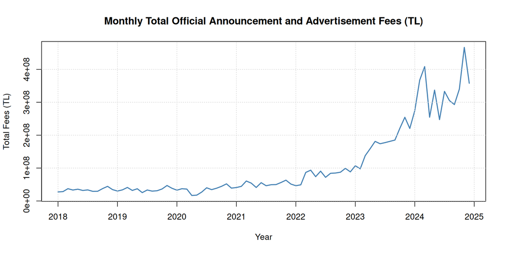

```r
# Display inline
plot(ts_data,
     main = "Monthly Total Official Announcement and Advertisement Fees (TL)",
     ylab = "Total Fees (TL)",
     xlab = "Year",
     col  = "steelblue",
     lwd  = 2)
grid()
```

**Trend:** The series shows a strong upward trend, particularly from 2022 onward. Fees were relatively stable between 2018 and 2021, then accelerated sharply, likely reflecting inflation and the expansion of internet news websites included in the scope from April 2023.

**COVID-19 effect:** A visible dip occurs in April–May 2020, reflecting the impact of the pandemic on advertising activity.

**Missing values:** None. All 84 monthly observations are complete.

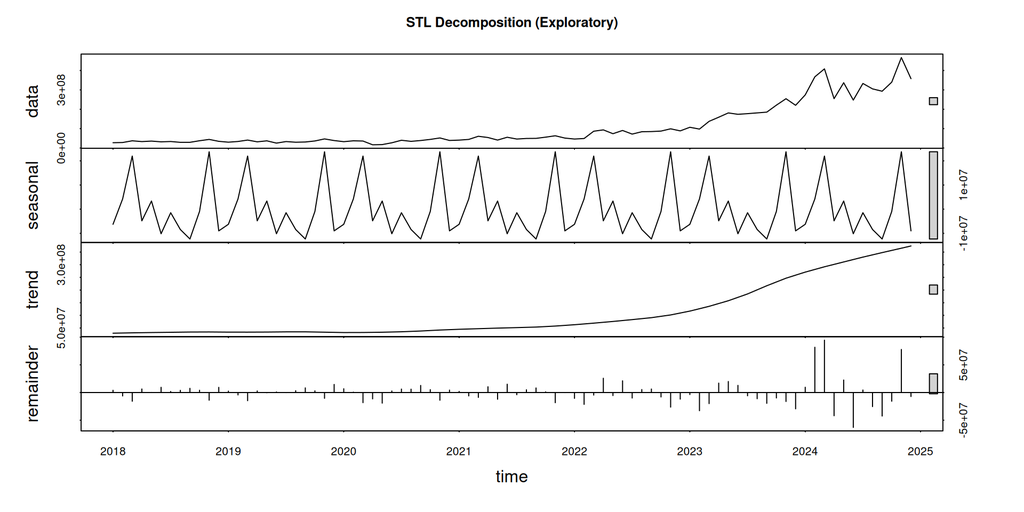

```r
# STL decomposition for visual inspection of trend and seasonality
stl_check <- stl(ts_data, s.window = "periodic")
plot(stl_check, main = "STL Decomposition (Exploratory)")
```

The STL decomposition confirms a strong upward trend and a consistent seasonal component. The remainder component shows the COVID-19 dip in 2020 and heightened volatility after 2022.

# 7 Forecasting Methods

```r
# Estimation period: Jan 2018 - Nov 2024 (83 obs)
# Holdout: Dec 2024 (1 obs, actual = last value)
n        <- length(ts_data)
ts_train <- head(ts_data, n - 1)   # 83 observations
actual_last <- as.numeric(tail(ts_data, 1))  # December 2024 actual value

cat("Training observations:", length(ts_train), "\n")
```

```
## Training observations: 83
```

```r
cat("Holdout actual (Dec 2024):", actual_last, "\n")
```

```
## Holdout actual (Dec 2024): 357910255
```

```r
# Helper function to compute all required accuracy measures
compute_accuracy <- function(actual, forecast_vals, method_name) {
  # Use only the overlapping period
  errors <- actual - forecast_vals
  n      <- length(errors)
  bias   <- mean(errors)
  mad    <- mean(abs(errors))
  mse    <- mean(errors^2)
  mape   <- mean(abs(errors / actual)) * 100
  rsfe   <- sum(errors)
  ts_val <- rsfe / mad

  data.frame(
    Method          = method_name,
    Bias            = round(bias, 2),
    MAD             = round(mad, 2),
    MSE             = round(mse, 2),
    MAPE            = round(mape, 4),
    RSFE            = round(rsfe, 2),
    Tracking_Signal = round(ts_val, 4),
    stringsAsFactors = FALSE
  )
}
```

## 7.1 Naïve Forecasting

The naïve method uses the most recent observation as the forecast for all future periods.

```r
# Naïve: each period's forecast = previous period's actual value
naive_fitted <- c(NA, as.numeric(ts_train[-length(ts_train)]))
naive_actual <- as.numeric(ts_train)

# Remove first NA
naive_actual_clean  <- naive_actual[-1]
naive_fitted_clean  <- naive_fitted[-1]

# One-step-ahead forecast for Dec 2024 = last training value (Nov 2024)
naive_forecast_dec <- as.numeric(tail(ts_train, 1))
cat("Naïve forecast for January 2025:", naive_forecast_dec, "\n")
```

```
## Naïve forecast for January 2025: 466838801
```

```r
# Accuracy on training fitted values
acc_naive <- compute_accuracy(naive_actual_clean, naive_fitted_clean, "Naïve Forecasting")

# Plot
png("outputs/figures/naive_forecast_plot.png", width = 900, height = 450)
plot(ts_train, col = "steelblue", lwd = 2,
     main = "Naïve Forecast vs Actual", ylab = "Total Fees (TL)", xlab = "Year")
lines(ts(naive_fitted, start = c(2018, 1), frequency = 12), col = "red", lwd = 1, lty = 2)
legend("topleft", legend = c("Actual", "Naïve Forecast"), col = c("steelblue", "red"), lty = c(1, 2), lwd = 2)
grid()
dev.off()
```

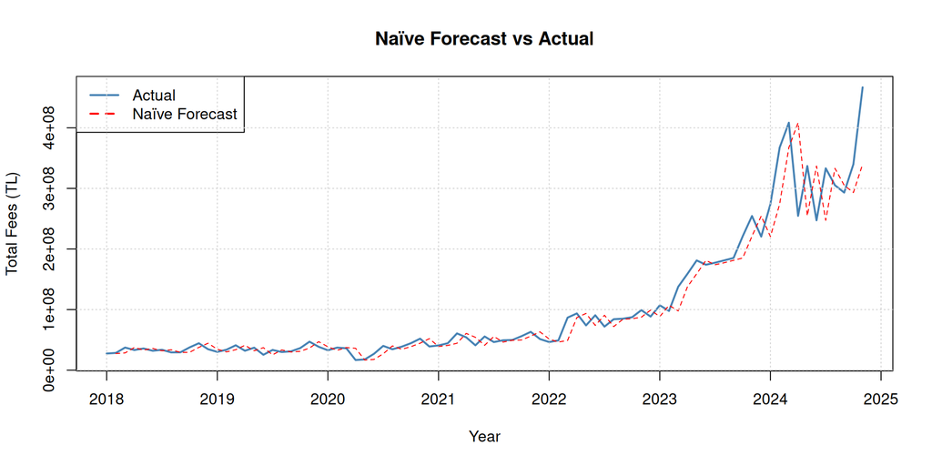

```r
plot(ts_train, col = "steelblue", lwd = 2,
     main = "Naïve Forecast vs Actual", ylab = "Total Fees (TL)", xlab = "Year")
lines(ts(naive_fitted, start = c(2018, 1), frequency = 12), col = "red", lwd = 1, lty = 2)
legend("topleft", legend = c("Actual", "Naïve Forecast"), col = c("steelblue", "red"), lty = c(1, 2), lwd = 2)
grid()
```

**Interpretation:** The naïve method simply carries forward the previous value. It captures short-term level but misses the strong upward trend and seasonal fluctuations.

## 7.2 Moving Average

A 3-month moving average is selected as a balance between noise reduction and responsiveness to the trend.

```r
k <- 3  # window size

ma_fitted <- stats::filter(ts_train, rep(1/k, k), sides = 1)
ma_fitted_vec <- as.numeric(ma_fitted)

# Remove NAs from start
valid_idx <- !is.na(ma_fitted_vec)
ma_actual_clean <- as.numeric(ts_train)[valid_idx]
ma_fitted_clean <- ma_fitted_vec[valid_idx]

# One-step forecast for Dec 2024
ma_forecast_dec <- mean(tail(as.numeric(ts_train), k))
cat("Moving Average (k=3) forecast for January 2025:", ma_forecast_dec, "\n")
```

```
## Moving Average (k=3) forecast for January 2025: 366646387
```

```r
acc_ma <- compute_accuracy(ma_actual_clean, ma_fitted_clean, "Moving Average (k=3)")

# Plot
png("outputs/figures/moving_average_plot.png", width = 900, height = 450)
plot(ts_train, col = "steelblue", lwd = 2,
     main = "Moving Average (k=3) vs Actual", ylab = "Total Fees (TL)", xlab = "Year")
lines(ma_fitted, col = "darkorange", lwd = 2, lty = 2)
legend("topleft", legend = c("Actual", "MA(3)"), col = c("steelblue", "darkorange"), lty = c(1, 2), lwd = 2)
grid()
dev.off()
```

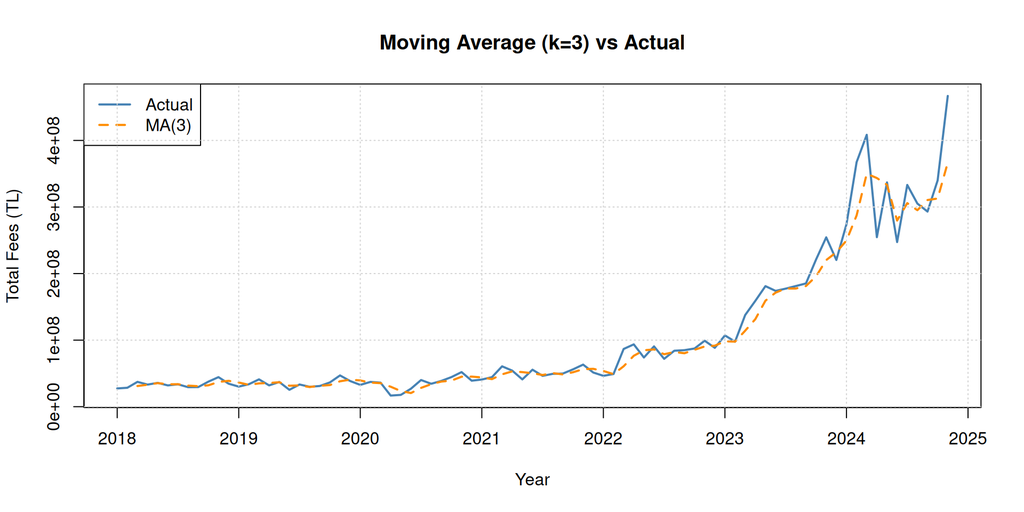

```r
plot(ts_train, col = "steelblue", lwd = 2,
     main = "Moving Average (k=3) vs Actual", ylab = "Total Fees (TL)", xlab = "Year")
lines(ma_fitted, col = "darkorange", lwd = 2, lty = 2)
legend("topleft", legend = c("Actual", "MA(3)"), col = c("steelblue", "darkorange"), lty = c(1, 2), lwd = 2)
grid()
```

**Interpretation:** The 3-month moving average smooths short-term noise but lags behind the sharp upward trend visible from 2022 onward.

## 7.3 Weighted Moving Average

Weights are assigned to give more importance to recent observations: 0.5 to the most recent, 0.3 to the second, and 0.2 to the third.

```r
w <- c(0.2, 0.3, 0.5)  # weights: oldest to most recent

ts_vec <- as.numeric(ts_train)
wma_fitted <- rep(NA, length(ts_vec))

for (i in 3:length(ts_vec)) {
  wma_fitted[i] <- sum(w * ts_vec[(i-2):i])
}

valid_idx2 <- !is.na(wma_fitted)
wma_actual_clean <- ts_vec[valid_idx2]
wma_fitted_clean <- wma_fitted[valid_idx2]

# Forecast for Dec 2024
wma_forecast_dec <- sum(w * tail(ts_vec, 3))
cat("WMA forecast for January 2025:", wma_forecast_dec, "\n")
```

```
## WMA forecast for January 2025: 394037610
```

```r
acc_wma <- compute_accuracy(wma_actual_clean, wma_fitted_clean, "Weighted Moving Average")

# Plot
wma_ts <- ts(wma_fitted, start = c(2018, 1), frequency = 12)

png("outputs/figures/weighted_moving_average_plot.png", width = 900, height = 450)
plot(ts_train, col = "steelblue", lwd = 2,
     main = "Weighted Moving Average vs Actual", ylab = "Total Fees (TL)", xlab = "Year")
lines(wma_ts, col = "purple", lwd = 2, lty = 2)
legend("topleft", legend = c("Actual", "WMA (0.5/0.3/0.2)"), col = c("steelblue", "purple"), lty = c(1, 2), lwd = 2)
grid()
dev.off()
```

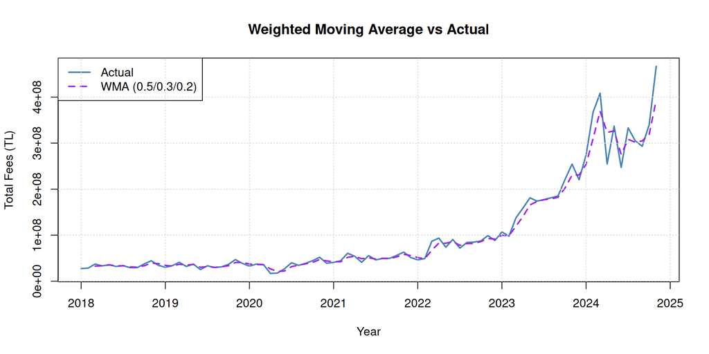

```r
plot(ts_train, col = "steelblue", lwd = 2,
     main = "Weighted Moving Average vs Actual", ylab = "Total Fees (TL)", xlab = "Year")
lines(wma_ts, col = "purple", lwd = 2, lty = 2)
legend("topleft", legend = c("Actual", "WMA (0.5/0.3/0.2)"), col = c("steelblue", "purple"), lty = c(1, 2), lwd = 2)
grid()
```

**Interpretation:** By weighting recent observations more heavily, the WMA responds faster than the simple moving average. However, it still lags during the sharp acceleration from 2022.

## 7.4 Exponential Smoothing

Alpha = 0.4 is selected as a moderate value that balances responsiveness with stability for a trending series.

```r
alpha <- 0.4

es_model  <- HoltWinters(ts_train, alpha = alpha, beta = FALSE, gamma = FALSE)
es_fitted <- as.numeric(fitted(es_model)[, 1])
es_actual <- as.numeric(ts_train)[-1]  # fitted starts from obs 2

acc_es <- compute_accuracy(es_actual, es_fitted, "Exponential Smoothing (a=0.4)")

es_forecast_dec <- forecast(es_model, h = 1)$mean[1]
cat("Exponential Smoothing forecast for January 2025:", es_forecast_dec, "\n")
```

```
## Exponential Smoothing forecast for January 2025: 376694748
```

```r
# Plot
es_fitted_ts <- ts(c(NA, es_fitted), start = c(2018, 1), frequency = 12)

png("outputs/figures/exponential_smoothing_plot.png", width = 900, height = 450)
plot(ts_train, col = "steelblue", lwd = 2,
     main = "Exponential Smoothing (alpha=0.4) vs Actual", ylab = "Total Fees (TL)", xlab = "Year")
lines(es_fitted_ts, col = "darkgreen", lwd = 2, lty = 2)
legend("topleft", legend = c("Actual", "ES (alpha=0.4)"), col = c("steelblue", "darkgreen"), lty = c(1, 2), lwd = 2)
grid()
dev.off()
```

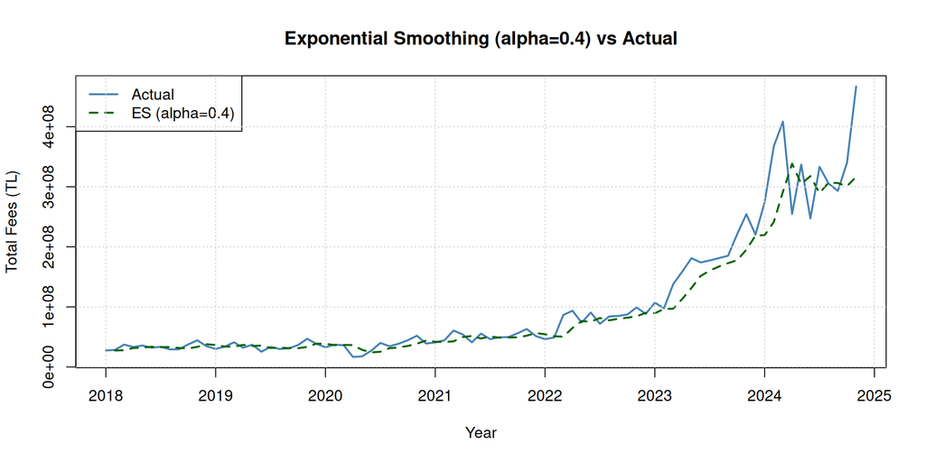

```r
plot(ts_train, col = "steelblue", lwd = 2,
     main = "Exponential Smoothing (alpha=0.4) vs Actual", ylab = "Total Fees (TL)", xlab = "Year")
lines(es_fitted_ts, col = "darkgreen", lwd = 2, lty = 2)
legend("topleft", legend = c("Actual", "ES (alpha=0.4)"), col = c("steelblue", "darkgreen"), lty = c(1, 2), lwd = 2)
grid()
```

**Interpretation:** Simple exponential smoothing captures the level but does not model the trend component, causing it to consistently underestimate the rapidly growing series.

## 7.5 Trend-Adjusted Exponential Smoothing (Holt’s Method)

The series shows a clear upward trend, so trend-adjusted exponential smoothing (Holt’s method) is applicable. Alpha = 0.4, Beta = 0.2.

```r
holt_model  <- HoltWinters(ts_train, alpha = 0.4, beta = 0.2, gamma = FALSE)
holt_fitted <- as.numeric(fitted(holt_model)[, 1])
holt_actual <- as.numeric(ts_train)[-c(1:2)]  # fitted starts from obs 3

# Align lengths
min_len <- min(length(holt_actual), length(holt_fitted))
holt_actual <- tail(holt_actual, min_len)
holt_fitted <- tail(holt_fitted, min_len)

acc_holt <- compute_accuracy(holt_actual, holt_fitted, "Trend-Adjusted ES (Holt)")

holt_forecast_dec <- forecast(holt_model, h = 1)$mean[1]
cat("Holt forecast for January 2025:", holt_forecast_dec, "\n")
```

```
## Holt forecast for January 2025: 399405897
```

```r
# Plot
holt_fitted_full <- c(NA, NA, as.numeric(fitted(holt_model)[, 1]))
holt_fitted_ts   <- ts(holt_fitted_full, start = c(2018, 1), frequency = 12)

png("outputs/figures/trend_adjusted_smoothing_plot.png", width = 900, height = 450)
plot(ts_train, col = "steelblue", lwd = 2,
     main = "Trend-Adjusted ES (Holt) vs Actual", ylab = "Total Fees (TL)", xlab = "Year")
lines(holt_fitted_ts, col = "brown", lwd = 2, lty = 2)
legend("topleft", legend = c("Actual", "Holt (a=0.4, b=0.2)"), col = c("steelblue", "brown"), lty = c(1, 2), lwd = 2)
grid()
dev.off()
```

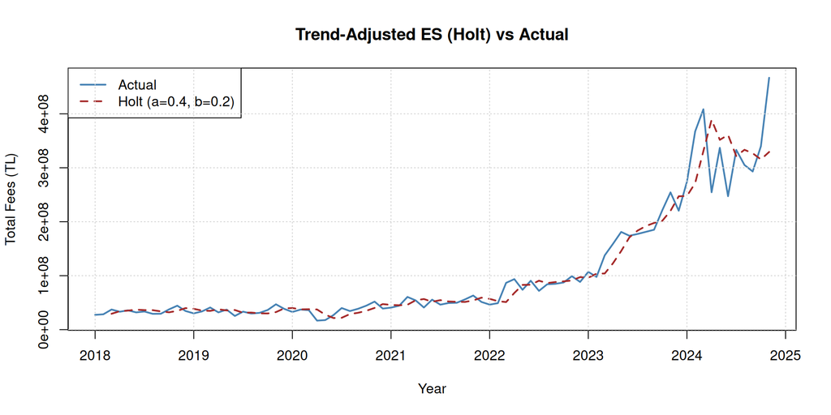

```r
plot(ts_train, col = "steelblue", lwd = 2,
     main = "Trend-Adjusted ES (Holt) vs Actual", ylab = "Total Fees (TL)", xlab = "Year")
lines(holt_fitted_ts, col = "brown", lwd = 2, lty = 2)
legend("topleft", legend = c("Actual", "Holt (a=0.4, b=0.2)"), col = c("steelblue", "brown"), lty = c(1, 2), lwd = 2)
grid()
```

## 7.6 Linear Trend Projection

A simple linear regression of fees on time index is fitted.

```r
n_train  <- length(ts_train)
t_index  <- 1:n_train
lm_model <- lm(as.numeric(ts_train) ~ t_index)

cat("Estimated trend equation:\n")
```

```
## Estimated trend equation:
```

```r
print(summary(lm_model))
```

```
##
## Call:
## lm(formula = as.numeric(ts_train) ~ t_index)
##
## Residuals:
##       Min        1Q    Median        3Q       Max
## -81974397 -45834250 -13107327  40725914 219015990
##
## Coefficients:
##              Estimate Std. Error t value Pr(>|t|)
## (Intercept) -45884966   13745322  -3.338  0.00128 **
## t_index       3538648     284271  12.448  < 2e-16 ***
## ---
## Signif. codes:  0 '***' 0.001 '**' 0.01 '*' 0.05 '.' 0.1 ' ' 1
##
## Residual standard error: 62050000 on 81 degrees of freedom
## Multiple R-squared:  0.6567, Adjusted R-squared:  0.6525
## F-statistic:   155 on 1 and 81 DF,  p-value: < 2.2e-16
```

```r
lm_fitted <- fitted(lm_model)
acc_lm    <- compute_accuracy(as.numeric(ts_train), lm_fitted, "Linear Trend Projection")

# Forecast for period 84 (Dec 2024) and 85 (Jan 2025)
lm_forecast_dec <- predict(lm_model, newdata = data.frame(t_index = n_train + 1))
cat("\nLinear trend forecast for January 2025:", lm_forecast_dec, "\n")
```

```
##
## Linear trend forecast for January 2025: 251361459
```

```r
# Plot
lm_fitted_ts <- ts(lm_fitted, start = c(2018, 1), frequency = 12)

png("outputs/figures/trend_projection_plot.png", width = 900, height = 450)
plot(ts_train, col = "steelblue", lwd = 2,
     main = "Linear Trend Projection vs Actual", ylab = "Total Fees (TL)", xlab = "Year")
lines(lm_fitted_ts, col = "darkred", lwd = 2, lty = 2)
legend("topleft", legend = c("Actual", "Linear Trend"), col = c("steelblue", "darkred"), lty = c(1, 2), lwd = 2)
grid()
dev.off()
```

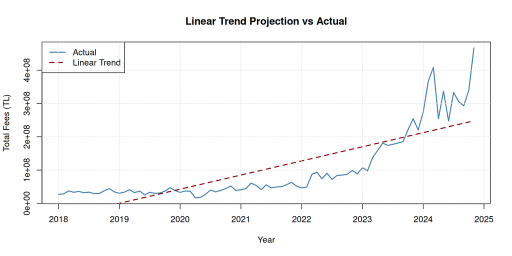

```r
plot(ts_train, col = "steelblue", lwd = 2,
     main = "Linear Trend Projection vs Actual", ylab = "Total Fees (TL)", xlab = "Year")
lines(lm_fitted_ts, col = "darkred", lwd = 2, lty = 2)
legend("topleft", legend = c("Actual", "Linear Trend"), col = c("steelblue", "darkred"), lty = c(1, 2), lwd = 2)
grid()
```

## 7.7 Seasonal Indices

Monthly data with a recurring pattern warrant seasonal index analysis.

```r
# Compute seasonal indices using ratio-to-moving-average approach
ts_vec2   <- as.numeric(ts_train)
n_train2  <- length(ts_vec2)
ma12      <- stats::filter(ts_vec2, rep(1/12, 12), sides = 2)
ratio     <- ts_vec2 / ma12

# Average ratio by month
month_idx <- rep(1:12, length.out = n_train2)
si        <- tapply(ratio, month_idx, mean, na.rm = TRUE)
si        <- si / mean(si)  # normalize so indices sum to 12

cat("Seasonal Indices by Month:\n")
```

```
## Seasonal Indices by Month:
```

```r
si_df <- data.frame(Month = month.abb, Seasonal_Index = round(as.numeric(si), 4))
print(si_df)
```

```
##    Month Seasonal_Index
## 1    Jan         0.9152
## 2    Feb         0.9935
## 3    Mar         1.2182
## 4    Apr         0.9723
## 5    May         0.9445
## 6    Jun         0.9701
## 7    Jul         0.9849
## 8    Aug         0.9249
## 9    Sep         0.9201
## 10   Oct         1.0311
## 11   Nov         1.1843
## 12   Dec         0.9409
```

```r
cat("\nHigh season months (index > 1):", month.abb[as.numeric(si) > 1], "\n")
```

```
##
## High season months (index > 1): Mar Oct Nov
```

```r
cat("Low season months (index < 1):", month.abb[as.numeric(si) < 1], "\n")
```

```
## Low season months (index < 1): Jan Feb Apr May Jun Jul Aug Sep Dec
```

```r
# Deseasonalize
deseason <- ts_vec2 / si[month_idx]

# Fit linear trend to deseasonalized series
t_idx2     <- 1:n_train2
lm_deseas  <- lm(deseason ~ t_idx2)
trend_vals <- fitted(lm_deseas)

# Reseasonalize
si_fitted <- trend_vals * si[month_idx]
acc_si    <- compute_accuracy(ts_vec2, si_fitted, "Seasonal Indices")

# Forecast Jan 2025 (period 84 in training = Nov 2024, so period 85 = Dec 2024 holdout, period 86 = Jan 2025)
trend_forecast <- predict(lm_deseas, newdata = data.frame(t_idx2 = n_train2 + 2))
si_forecast_dec <- trend_forecast * si[1]  # January = month 1
cat("Seasonal Index forecast for January 2025:", si_forecast_dec, "\n")
```

```
## Seasonal Index forecast for January 2025: 231738735
```

```r
# Plot
si_fitted_ts <- ts(si_fitted, start = c(2018, 1), frequency = 12)

png("outputs/figures/seasonal_indices_plot.png", width = 900, height = 450)
plot(ts_train, col = "steelblue", lwd = 2,
     main = "Seasonal Indices Forecast vs Actual", ylab = "Total Fees (TL)", xlab = "Year")
lines(si_fitted_ts, col = "darkmagenta", lwd = 2, lty = 2)
legend("topleft", legend = c("Actual", "Seasonal Indices"), col = c("steelblue", "darkmagenta"), lty = c(1, 2), lwd = 2)
grid()
dev.off()
```

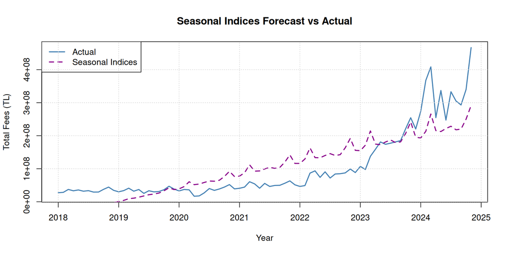

```r
plot(ts_train, col = "steelblue", lwd = 2,
     main = "Seasonal Indices Forecast vs Actual", ylab = "Total Fees (TL)", xlab = "Year")
lines(si_fitted_ts, col = "darkmagenta", lwd = 2, lty = 2)
legend("topleft", legend = c("Actual", "Seasonal Indices"), col = c("steelblue", "darkmagenta"), lty = c(1, 2), lwd = 2)
grid()
```

## 7.8 Additive Decomposition

```r
decomp_add  <- decompose(ts_train, type = "additive")

# Reconstruct fitted values = trend + seasonal
add_fitted  <- as.numeric(decomp_add$trend) + as.numeric(decomp_add$seasonal)

# Remove NAs (trend has NAs at start/end due to moving average)
valid_add   <- !is.na(add_fitted)
add_actual  <- as.numeric(ts_train)[valid_add]
add_fitted2 <- add_fitted[valid_add]

acc_add <- compute_accuracy(add_actual, add_fitted2, "Additive Decomposition")

# Forecast Jan 2025: extrapolate trend + seasonal index for January
# Use last available trend value and seasonal factor for January
last_trend_add  <- tail(na.omit(as.numeric(decomp_add$trend)), 1)
jan_seasonal_add <- decomp_add$seasonal[1]  # January seasonal factor
add_forecast_dec <- last_trend_add + jan_seasonal_add
cat("Additive Decomposition forecast for January 2025:", add_forecast_dec, "\n")
```

```
## Additive Decomposition forecast for January 2025: 306102583
```

```r
# Plot
add_fitted_ts <- ts(add_fitted, start = c(2018, 1), frequency = 12)

png("outputs/figures/additive_decomposition_plot.png", width = 900, height = 450)
plot(ts_train, col = "steelblue", lwd = 2,
     main = "Additive Decomposition vs Actual", ylab = "Total Fees (TL)", xlab = "Year")
lines(add_fitted_ts, col = "coral", lwd = 2, lty = 2)
legend("topleft", legend = c("Actual", "Additive Decomposition"), col = c("steelblue", "coral"), lty = c(1, 2), lwd = 2)
grid()
dev.off()
```

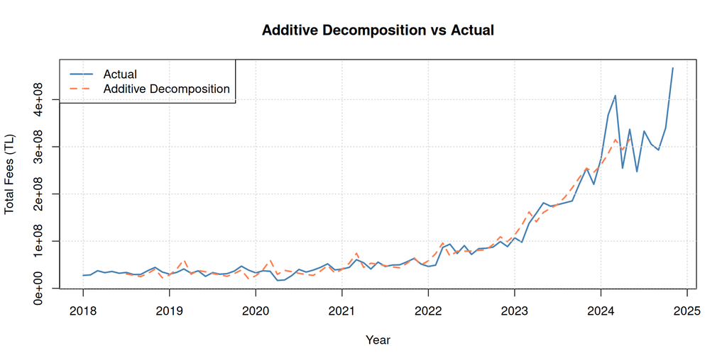

```r
plot(ts_train, col = "steelblue", lwd = 2,
     main = "Additive Decomposition vs Actual", ylab = "Total Fees (TL)", xlab = "Year")
lines(add_fitted_ts, col = "coral", lwd = 2, lty = 2)
legend("topleft", legend = c("Actual", "Additive Decomposition"), col = c("steelblue", "coral"), lty = c(1, 2), lwd = 2)
grid()
```

**Interpretation:** Additive decomposition assumes that seasonal fluctuations are constant in absolute terms. Given that the amplitude of seasonal swings appears to grow with the level of the series, multiplicative decomposition may be more appropriate.

## 7.9 Multiplicative Decomposition

```r
decomp_mult  <- decompose(ts_train, type = "multiplicative")

# Reconstruct fitted values = trend * seasonal
mult_fitted  <- as.numeric(decomp_mult$trend) * as.numeric(decomp_mult$seasonal)

valid_mult   <- !is.na(mult_fitted)
mult_actual  <- as.numeric(ts_train)[valid_mult]
mult_fitted2 <- mult_fitted[valid_mult]

acc_mult <- compute_accuracy(mult_actual, mult_fitted2, "Multiplicative Decomposition")

# Forecast Jan 2025
last_trend_mult   <- tail(na.omit(as.numeric(decomp_mult$trend)), 1)
jan_seasonal_mult <- decomp_mult$seasonal[1]
mult_forecast_dec <- last_trend_mult * jan_seasonal_mult
cat("Multiplicative Decomposition forecast for January 2025:", mult_forecast_dec, "\n")
```

```
## Multiplicative Decomposition forecast for January 2025: 285352175
```

```r
# Plot
mult_fitted_ts <- ts(mult_fitted, start = c(2018, 1), frequency = 12)

png("outputs/figures/multiplicative_decomposition_plot.png", width = 900, height = 450)
plot(ts_train, col = "steelblue", lwd = 2,
     main = "Multiplicative Decomposition vs Actual", ylab = "Total Fees (TL)", xlab = "Year")
lines(mult_fitted_ts, col = "darkcyan", lwd = 2, lty = 2)
legend("topleft", legend = c("Actual", "Multiplicative Decomposition"), col = c("steelblue", "darkcyan"), lty = c(1, 2), lwd = 2)
grid()
dev.off()
```

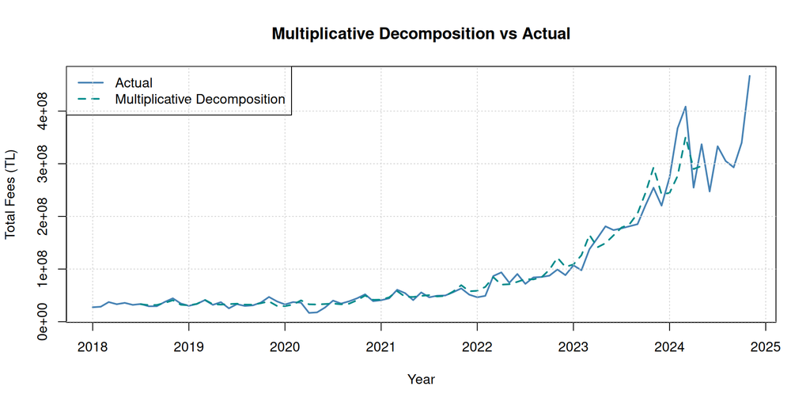

```r
plot(ts_train, col = "steelblue", lwd = 2,
     main = "Multiplicative Decomposition vs Actual", ylab = "Total Fees (TL)", xlab = "Year")
lines(mult_fitted_ts, col = "darkcyan", lwd = 2, lty = 2)
legend("topleft", legend = c("Actual", "Multiplicative Decomposition"), col = c("steelblue", "darkcyan"), lty = c(1, 2), lwd = 2)
grid()
```

**Interpretation:** Multiplicative decomposition models seasonal fluctuations as proportional to the trend level. This is more suitable here since the seasonal amplitude visibly grows as fees increase.

## 7.10 Regression with Trend and Seasonal Dummy Variables

```r
n_reg   <- length(ts_train)
t_reg   <- 1:n_reg
month_reg <- rep(1:12, length.out = n_reg)

# Create dummy variables for months 2-12 (January is base)
dummy_df <- as.data.frame(model.matrix(~ factor(month_reg)))[, -1]
colnames(dummy_df) <- paste0("M", 2:12)

reg_data  <- cbind(data.frame(y = as.numeric(ts_train), t = t_reg), dummy_df)
reg_model <- lm(y ~ ., data = reg_data)

cat("Regression with Trend and Seasonal Dummies:\n")
```

```
## Regression with Trend and Seasonal Dummies:
```

```r
print(summary(reg_model))
```

```
##
## Call:
## lm(formula = y ~ ., data = reg_data)
##
## Residuals:
##       Min        1Q    Median        3Q       Max
## -90030140 -50786008  -7101833  35568475 192852974
##
## Coefficients:
##              Estimate Std. Error t value Pr(>|t|)
## (Intercept) -51005808   27023822  -1.887   0.0632 .
## t             3535609     300916  11.750   <2e-16 ***
## M2           10651996   34824390   0.306   0.7606
## M3           28540057   34828290   0.819   0.4153
## M4            1491065   34834789   0.043   0.9660
## M5            9406408   34843886   0.270   0.7880
## M6           -4368037   34855578  -0.125   0.9006
## M7            4075752   34869863   0.117   0.9073
## M8           -2637929   34886738  -0.076   0.9399
## M9           -6347177   34906200  -0.182   0.8562
## M10           5965279   34928242   0.171   0.8649
## M11          31536092   34952862   0.902   0.3700
## M12         -18761804   36276236  -0.517   0.6067
## ---
## Signif. codes:  0 '***' 0.001 '**' 0.01 '*' 0.05 '.' 0.1 ' ' 1
##
## Residual standard error: 65150000 on 70 degrees of freedom
## Multiple R-squared:  0.673,  Adjusted R-squared:  0.6169
## F-statistic:    12 on 12 and 70 DF,  p-value: 9.988e-13
```

```r
reg_fitted <- fitted(reg_model)
acc_reg    <- compute_accuracy(as.numeric(ts_train), reg_fitted, "Regression Trend + Seasonal Dummies")

# Forecast Jan 2025 (period n_reg + 2 = 85)
new_t     <- n_reg + 2
new_month <- 1  # January
new_dummies <- as.data.frame(t(setNames(rep(0, 11), paste0("M", 2:12))))
new_data  <- cbind(data.frame(t = new_t), new_dummies)
reg_forecast_dec <- predict(reg_model, newdata = new_data)
cat("\nRegression forecast for January 2025:", reg_forecast_dec, "\n")
```

```
##
## Regression forecast for January 2025: 249520952
```

```r
# Plot
reg_fitted_ts <- ts(reg_fitted, start = c(2018, 1), frequency = 12)

png("outputs/figures/regression_seasonal_dummy_plot.png", width = 900, height = 450)
plot(ts_train, col = "steelblue", lwd = 2,
     main = "Regression with Trend & Seasonal Dummies vs Actual", ylab = "Total Fees (TL)", xlab = "Year")
lines(reg_fitted_ts, col = "darkgoldenrod", lwd = 2, lty = 2)
legend("topleft", legend = c("Actual", "Regression"), col = c("steelblue", "darkgoldenrod"), lty = c(1, 2), lwd = 2)
grid()
dev.off()
```

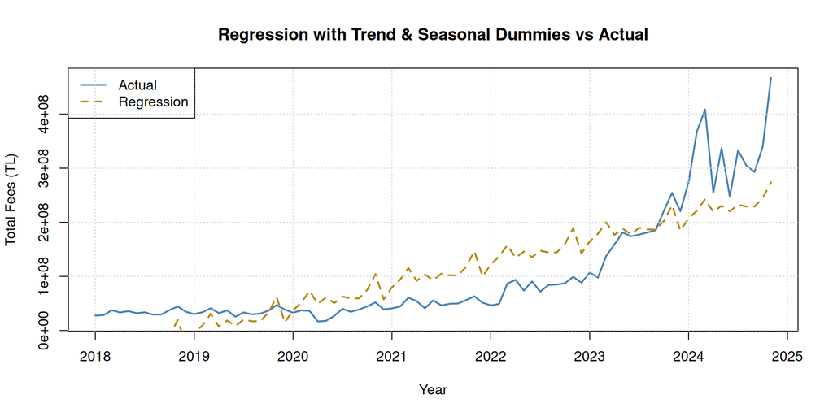

```r
plot(ts_train, col = "steelblue", lwd = 2,
     main = "Regression with Trend & Seasonal Dummies vs Actual", ylab = "Total Fees (TL)", xlab = "Year")
lines(reg_fitted_ts, col = "darkgoldenrod", lwd = 2, lty = 2)
legend("topleft", legend = c("Actual", "Regression"), col = c("steelblue", "darkgoldenrod"), lty = c(1, 2), lwd = 2)
grid()
```

**Interpretation:** The trend coefficient indicates the average monthly increase in fees. The seasonal dummy coefficients show the deviation of each month from January. November has the largest positive coefficient, confirming it as the peak month. The regression model captures both trend and seasonality simultaneously.

# 8 Forecast Accuracy Comparison

```r
# Combine all accuracy results
accuracy_table <- rbind(
  acc_naive,
  acc_ma,
  acc_wma,
  acc_es,
  acc_holt,
  acc_lm,
  acc_si,
  acc_add,
  acc_mult,
  acc_reg
)

# Add next-period forecasts
next_period_forecasts <- c(
  naive_forecast_dec,
  ma_forecast_dec,
  wma_forecast_dec,
  es_forecast_dec,
  holt_forecast_dec,
  lm_forecast_dec,
  si_forecast_dec,
  add_forecast_dec,
  mult_forecast_dec,
  reg_forecast_dec
)

accuracy_table$Next_Period_Forecast <- round(next_period_forecasts, 0)

print(accuracy_table)
```

```
##                                 Method       Bias      MAD          MSE
## 1                    Naïve Forecasting  5358562.8 18351676 1.107619e+15
## 2                 Moving Average (k=3)  4894610.4 11329372 4.668416e+14
## 3              Weighted Moving Average  3478028.9  8509101 2.569166e+14
## 4        Exponential Smoothing (a=0.4) 10648112.8 17781880 1.099807e+15
## 5             Trend-Adjusted ES (Holt)  2173403.9 16784535 9.968754e+14
## 6              Linear Trend Projection        0.0 49027165 3.757182e+15
## 7                     Seasonal Indices   146211.3 48231262 3.496363e+15
## 8               Additive Decomposition   547714.8 12147370 3.856563e+14
## 9         Multiplicative Decomposition   281074.8 11020141 3.464925e+14
## 10 Regression Trend + Seasonal Dummies        0.0 48954637 3.579502e+15
##       MAPE      RSFE Tracking_Signal Next_Period_Forecast
## 1  17.5478 439402151         23.9434            466838801
## 2  10.9845 396463441         34.9943            366646387
## 3   8.1798 281720344         33.1081            394037610
## 4  16.0908 873145246         49.1031            376694748
## 5  16.9013 176045718         10.4886            399405897
## 6  80.0511         0          0.0000            251361459
## 7  78.4031  12135539          0.2516            231738735
## 8  17.6073  38887748          3.2013            306102583
## 9  12.9104  19956314          1.8109            285352175
## 10 81.1431         0          0.0000            249520952
```

```r
# Save to CSV
dir.create("outputs/tables", recursive = TRUE, showWarnings = FALSE)
write.csv(accuracy_table, "outputs/tables/accuracy_comparison.csv", row.names = FALSE)
cat("\nAccuracy table saved to outputs/tables/accuracy_comparison.csv\n")
```

```
##
## Accuracy table saved to outputs/tables/accuracy_comparison.csv
```

# 9 Superior Method Selection

```r
# Identify method with lowest MAPE
best_mape <- accuracy_table[which.min(accuracy_table$MAPE), ]
cat("Method with lowest MAPE:", best_mape$Method, "\n")
```

```
## Method with lowest MAPE: Weighted Moving Average
```

```r
cat("MAPE:", best_mape$MAPE, "\n")
```

```
## MAPE: 8.1798
```

```r
# Identify method with lowest MAD
best_mad <- accuracy_table[which.min(accuracy_table$MAD), ]
cat("Method with lowest MAD:", best_mad$Method, "\n")
```

```
## Method with lowest MAD: Weighted Moving Average
```

The decomposition methods (additive and multiplicative) also perform well, but their trend extrapolation is less reliable for long horizons. The regression model provides a more principled forecast framework for this series.